# week 6: integers and other monsters

ordered categories

```r
library(tidyverse)
library(psych)
library(cowplot)
library(patchwork)
library(here)
library(brms)
library(tidybayes)
```

## Ordered categorical outcomes

Ordered categories are variables that are discrete, like a count, except that the values merely indicate different ordered levels.[^1] Most Likert scale questions are ordered categories, even though we pretend they’re continuous (see polychoric correlations).

If we want to model an outcome as an ordered categorical variable, what we’re really asking is how does moving along an associated predictor variable move predictions in the outcome progressively through the categories *in sequence*. We must therefore model our outcomes in the right order.

To do so, we’ll use the principles of the generalized linear model discussed last week. That is, we use a link function – the **CUMULATIVE LINK FUNCTION** – to model the probability of a value that is that value or smaller.

### example: the trolley problem

```r
data(Trolley, package = "rethinking")
trolley <- Trolley
glimpse(trolley)
```

```
## Rows: 9,930
## Columns: 12
## $ case      <fct> cfaqu, cfbur, cfrub, cibox, cibur, cispe, fkaqu, fkboa, fkbo…
## $ response  <int> 4, 3, 4, 3, 3, 3, 5, 4, 4, 4, 4, 4, 4, 5, 4, 4, 4, 4, 4, 3, …
## $ order     <int> 2, 31, 16, 32, 4, 9, 29, 12, 23, 22, 27, 19, 14, 3, 18, 15, …
## $ id        <fct> 96;434, 96;434, 96;434, 96;434, 96;434, 96;434, 96;434, 96;4…
## $ age       <int> 14, 14, 14, 14, 14, 14, 14, 14, 14, 14, 14, 14, 14, 14, 14, …
## $ male      <int> 0, 0, 0, 0, 0, 0, 0, 0, 0, 0, 0, 0, 0, 0, 0, 0, 0, 0, 0, 0, …
## $ edu       <fct> Middle School, Middle School, Middle School, Middle School, …
## $ action    <int> 0, 0, 0, 0, 0, 0, 1, 1, 1, 1, 1, 1, 1, 0, 0, 0, 0, 0, 1, 1, …
## $ intention <int> 0, 0, 0, 1, 1, 1, 0, 0, 0, 0, 0, 0, 0, 0, 0, 0, 0, 0, 1, 1, …
## $ contact   <int> 1, 1, 1, 1, 1, 1, 0, 0, 0, 0, 0, 0, 0, 0, 0, 0, 0, 0, 0, 0, …
## $ story     <fct> aqu, bur, rub, box, bur, spe, aqu, boa, box, bur, car, spe, …
## $ action2   <int> 1, 1, 1, 1, 1, 1, 1, 1, 1, 1, 1, 1, 1, 0, 0, 0, 0, 0, 1, 1, …
```

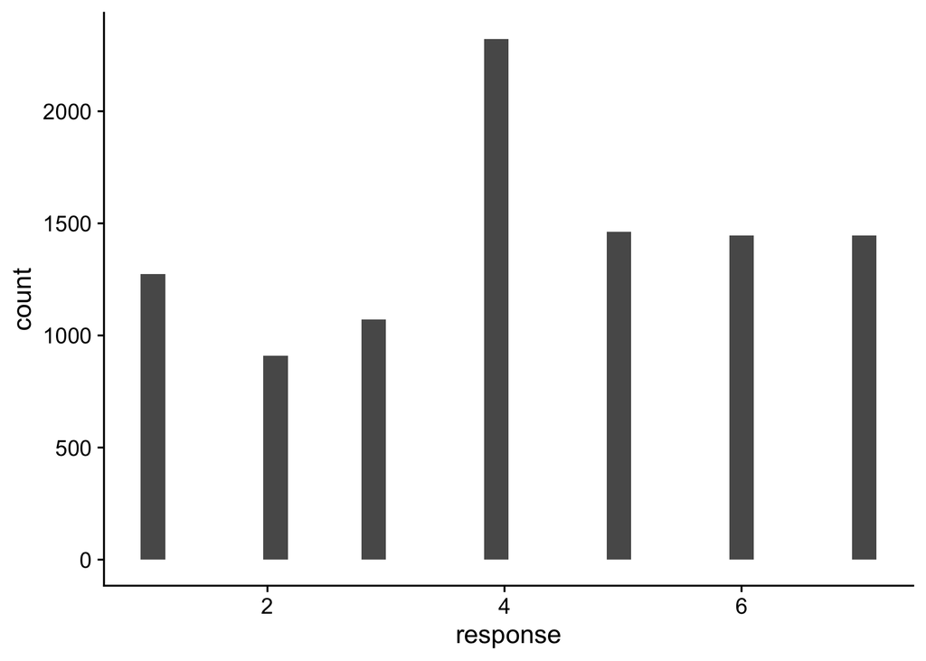

```r
trolley %>%
  ggplot(aes( x=response )) +
  geom_histogram()
```

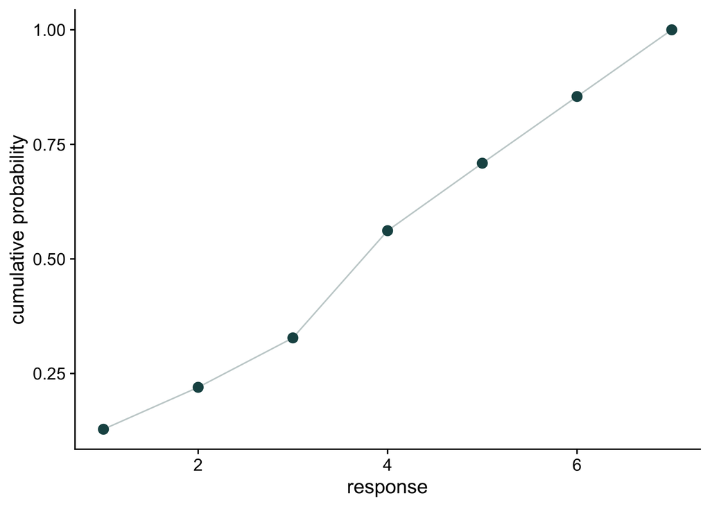

```r
trolley %>%
  count(response) %>%
  mutate(pr_k     = n/nrow(trolley),
         cum_pr_k = cumsum(pr_k)) %>%
  ggplot(aes(x = response, y = cum_pr_k)) +
  geom_point(size = 3, color = "#1c5253") +
  geom_line(color = "#1c5253", alpha = .3) +
  labs(x = "response",
       y = "cumulative probability")
```

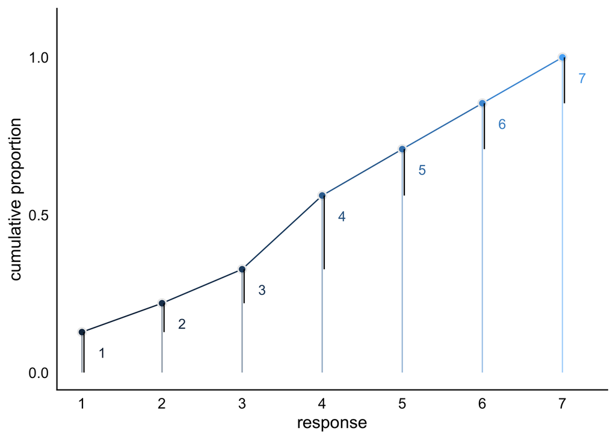

```r
# primary data
trolley_plot <-
  trolley %>%
  count(response) %>%
  mutate(pr_k     = n / nrow(trolley),
         cum_pr_k = cumsum(n / nrow(trolley))) %>%
  mutate(discrete_probability = ifelse(response == 1, cum_pr_k, cum_pr_k - pr_k))

# annotation
text <-
  tibble(text     = 1:7,
         response = seq(from = 1.25, to = 7.25, by = 1),
         cum_pr_k = trolley_plot$cum_pr_k - .065)

trolley_plot %>%
  ggplot(aes(x = response, y = cum_pr_k,
             color = cum_pr_k, fill = cum_pr_k)) +
  geom_line() +
  geom_point(shape = 21, colour = "grey92",
             size = 2.5, stroke = 1) +
  geom_linerange(aes(ymin = 0, ymax = cum_pr_k),
                 alpha = 1/2) +
  geom_linerange(aes(x = response + .025,
                     ymin = ifelse(response == 1, 0, discrete_probability),
                     ymax = cum_pr_k),
                 color = "black") +
  # number annotation
  geom_text(data = text,
            aes(label = text),
            size = 4) +
  scale_x_continuous(breaks = 1:7) +
  scale_y_continuous("cumulative proportion", breaks = c(0, .5, 1),
                     limits = c(0, 1.1)) +
  theme(axis.ticks = element_blank(),
        axis.title.y = element_text(angle = 90),
        legend.position = "none")
```

On to the modeling. We’ll start with an intercept-only model.

$$\begin{align*}
R_i &\sim \text{Categorical}(p) \\
\text{logit}(p_k) = \alpha_k - \phi
\phi_i &= 0 \\
\alpha_k &\sim \text{Normal}(0, 1.5)
\end{align*}$$

Remember, $\phi$ doesn’t have an intercept because there’s a $\alpha$ for each cut point.

```r
m1 <- brm(
  data = trolley,
  family = cumulative,
  response ~ 1,
  prior = c( prior(normal(0, 1.5), class = Intercept) ),
  iter=2000, warmup=1000, cores=4, chains=4,
  file=here("files/data/generated_data/m61.1")
)
```

```r
summary(m1)
```

```
##  Family: cumulative
##   Links: mu = logit; disc = identity
## Formula: response ~ 1
##    Data: trolley (Number of observations: 9930)
##   Draws: 4 chains, each with iter = 2000; warmup = 1000; thin = 1;
##          total post-warmup draws = 4000
##
## Regression Coefficients:
##              Estimate Est.Error l-95% CI u-95% CI Rhat Bulk_ESS Tail_ESS
## Intercept[1]    -1.92      0.03    -1.98    -1.86 1.00     3004     3065
## Intercept[2]    -1.27      0.02    -1.31    -1.22 1.00     4085     3449
## Intercept[3]    -0.72      0.02    -0.76    -0.68 1.00     4532     3499
## Intercept[4]     0.25      0.02     0.21     0.29 1.00     4697     3614
## Intercept[5]     0.89      0.02     0.85     0.93 1.00     4370     3119
## Intercept[6]     1.77      0.03     1.71     1.82 1.00     5091     3618
##
## Further Distributional Parameters:
##      Estimate Est.Error l-95% CI u-95% CI Rhat Bulk_ESS Tail_ESS
## disc     1.00      0.00     1.00     1.00   NA       NA       NA
##
## Draws were sampled using sampling(NUTS). For each parameter, Bulk_ESS
## and Tail_ESS are effective sample size measures, and Rhat is the potential
## scale reduction factor on split chains (at convergence, Rhat = 1).
```

```r
m1 %>%
  fixef() %>%
  inv_logit_scaled() %>%
  round(digits = 3)
```

```
##              Estimate Est.Error  Q2.5 Q97.5
## Intercept[1]    0.128     0.508 0.122 0.135
## Intercept[2]    0.220     0.506 0.212 0.228
## Intercept[3]    0.328     0.505 0.318 0.337
## Intercept[4]    0.562     0.505 0.552 0.571
## Intercept[5]    0.709     0.506 0.700 0.718
## Intercept[6]    0.854     0.507 0.847 0.861
```

Note: the standard errors (`Est.Error`) are not valid for this approach. (Just look at how they compare to the quantiles of the distribution.) Drawing from the posterior is the best solution to this.

```r
as_draws_df(m1) %>%
  mutate_at(vars(starts_with("b_")), inv_logit_scaled) %>%
  pivot_longer(starts_with("b_")) %>%
  group_by(name) %>%
  summarise(mean = mean(value),
            sd   = sd(value),
            ll   = quantile(value, probs = .025),
            ul   = quantile(value, probs = .975))
```

```
## # A tibble: 6 × 5
##   name            mean      sd    ll    ul
##   <chr>          <dbl>   <dbl> <dbl> <dbl>
## 1 b_Intercept[1] 0.128 0.00338 0.122 0.135
## 2 b_Intercept[2] 0.220 0.00411 0.212 0.228
## 3 b_Intercept[3] 0.328 0.00468 0.318 0.337
## 4 b_Intercept[4] 0.562 0.00499 0.552 0.571
## 5 b_Intercept[5] 0.709 0.00456 0.700 0.718
## 6 b_Intercept[6] 0.854 0.00351 0.847 0.861
```

### exercise

Create a plot showing the posterior predictive distribution for the intercept-only model (m1). Can you visualize both the posterior and the observed data?

### solution

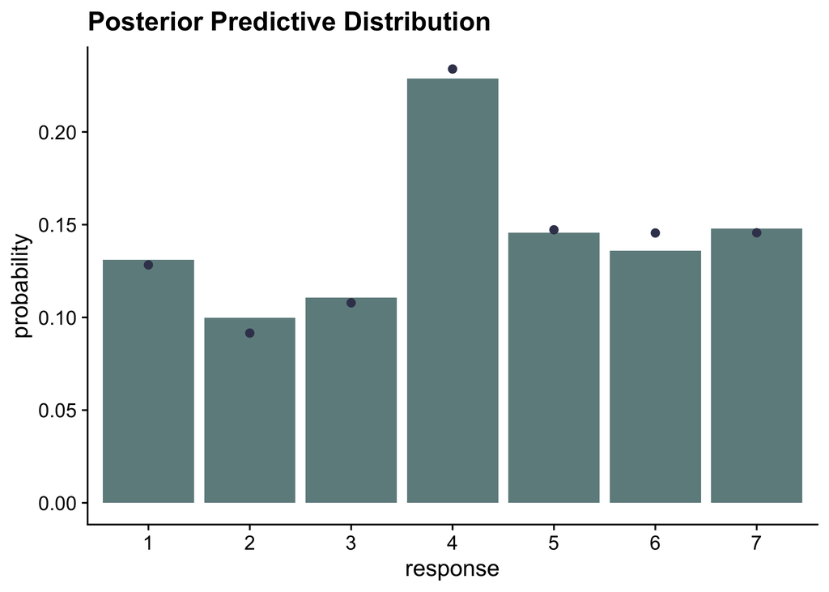

```r
predicted_draws(m1, newdata = data.frame(1)) %>%
  count(.prediction) %>%
  mutate(pr_k = n / sum(n)) %>%
  ggplot(aes(x = .prediction, y = pr_k)) +
  geom_col(fill = "#1c5253", alpha = 0.7) +
  geom_point(data = trolley_plot, aes(x = response),
             color = "#3d405b", size = 2) +
  labs(x = "response",
       y = "probability",
       title = "Posterior Predictive Distribution")
```

### adding predictors

Now let’s add the features of the story – contact, action, and intention – as predictors in our model. Let’s expand our mathematical model. Here’s our original:

$$\begin{align*}
R_i &\sim \text{Categorical}(p) \\
\text{logit}(p_k) = \alpha_k - \phi
\phi_i &= 0 \\
\alpha_k &\sim \text{Normal}(0, 1.5)
\end{align*}$$

McElreath proposes the following causal formula:

$$\phi_i = \beta_1\text{action}_i + \beta_2\text{contact}_i + (\beta_3 +
\beta_4\text{action}_i + \beta_5\text{contact}_i)\text{intention}_i$$

```r
m2 <- brm(
  data = trolley,
  family = cumulative,
  response ~ 1 + action + contact + intention + action:intention + contact:intention,
  prior = c( prior(normal(0, 1.5), class = Intercept),
             prior(normal(0, 0.5), class = b)),
  iter=2000, warmup=1000, cores=4, chains=4,
  file=here("files/data/generated_data/m61.2")
)

m2
```

```
##  Family: cumulative
##   Links: mu = logit; disc = identity
## Formula: response ~ 1 + action + contact + intention + action:intention + contact:intention
##    Data: trolley (Number of observations: 9930)
##   Draws: 4 chains, each with iter = 2000; warmup = 1000; thin = 1;
##          total post-warmup draws = 4000
##
## Regression Coefficients:
##                   Estimate Est.Error l-95% CI u-95% CI Rhat Bulk_ESS Tail_ESS
## Intercept[1]         -2.64      0.05    -2.74    -2.53 1.00     2973     2727
## Intercept[2]         -1.94      0.05    -2.04    -1.85 1.00     3113     2791
## Intercept[3]         -1.35      0.05    -1.44    -1.26 1.00     2979     3029
## Intercept[4]         -0.31      0.04    -0.40    -0.23 1.00     2785     2912
## Intercept[5]          0.36      0.04     0.27     0.44 1.00     2886     3000
## Intercept[6]          1.26      0.05     1.17     1.35 1.00     3129     2816
## action               -0.48      0.05    -0.58    -0.37 1.00     3072     2837
## contact              -0.35      0.07    -0.48    -0.21 1.00     3031     2820
## intention            -0.30      0.06    -0.41    -0.18 1.00     2694     2861
## action:intention     -0.43      0.08    -0.59    -0.27 1.00     2949     3105
## contact:intention    -1.23      0.10    -1.42    -1.05 1.00     2710     2794
##
## Further Distributional Parameters:
##      Estimate Est.Error l-95% CI u-95% CI Rhat Bulk_ESS Tail_ESS
## disc     1.00      0.00     1.00     1.00   NA       NA       NA
##
## Draws were sampled using sampling(NUTS). For each parameter, Bulk_ESS
## and Tail_ESS are effective sample size measures, and Rhat is the potential
## scale reduction factor on split chains (at convergence, Rhat = 1).
```

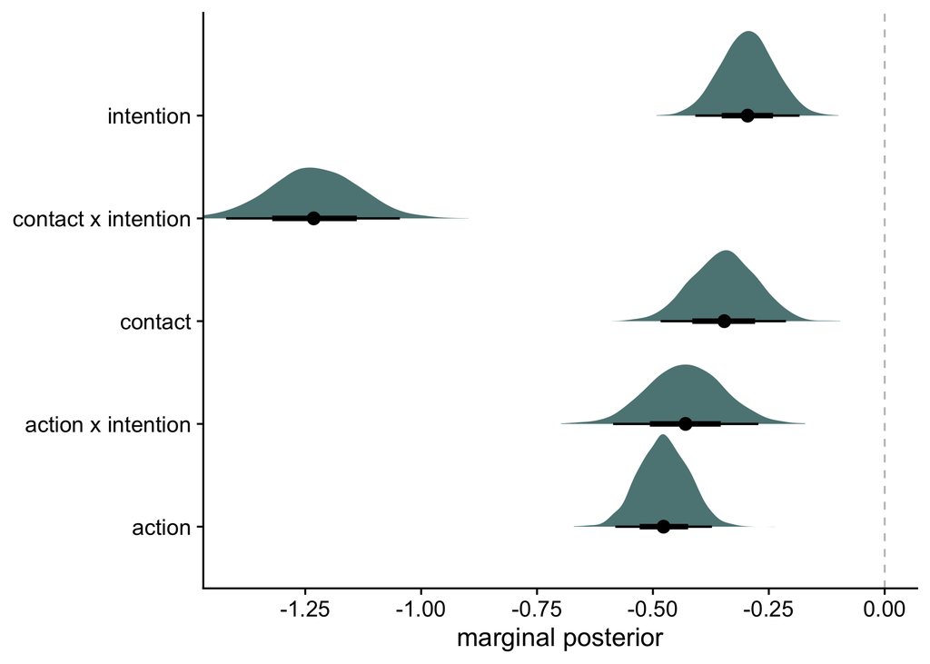

```r
as_draws_df(m2) %>%
  select(starts_with("b_")) %>%
  select(-matches("[0-9]")) %>%
  pivot_longer(everything()) %>%
  mutate(
    name = str_remove(name, "b_"),
    name = str_replace(name, ":", " x ")
  ) %>%
  ggplot( aes(x = value, y = name) ) +
  geom_vline( aes(xintercept = 0), linetype = "dashed", alpha = .3 ) +
  stat_dist_halfeye(fill = "#5e8485") +
  scale_x_continuous("marginal posterior", breaks = -5:0 / 4) +
  scale_y_discrete(NULL) +
  coord_cartesian(xlim = c(-1.4, 0))
```

```r
nd <-
  trolley %>%
  distinct(action, contact, intention) %>%
  mutate(combination = str_c(action, contact, intention, sep = "_"))

f <- predicted_draws( m2 , newdata = nd )

# what have we done?
f %>% str()
```

```
## gropd_df [24,000 × 9] (S3: grouped_df/tbl_df/tbl/data.frame)
##  $ action     : int [1:24000] 0 0 0 0 0 0 0 0 0 0 ...
##  $ contact    : int [1:24000] 1 1 1 1 1 1 1 1 1 1 ...
##  $ intention  : int [1:24000] 0 0 0 0 0 0 0 0 0 0 ...
##  $ combination: chr [1:24000] "0_1_0" "0_1_0" "0_1_0" "0_1_0" ...
##  $ .row       : int [1:24000] 1 1 1 1 1 1 1 1 1 1 ...
##  $ .chain     : int [1:24000] NA NA NA NA NA NA NA NA NA NA ...
##  $ .iteration : int [1:24000] NA NA NA NA NA NA NA NA NA NA ...
##  $ .draw      : int [1:24000] 1 2 3 4 5 6 7 8 9 10 ...
##  $ .prediction: Factor w/ 7 levels "1","2","3","4",..: 5 4 5 4 3 4 5 7 5 4 ...
##  - attr(*, "groups")= tibble [6 × 6] (S3: tbl_df/tbl/data.frame)
##   ..$ action     : int [1:6] 0 0 0 0 1 1
##   ..$ contact    : int [1:6] 0 0 1 1 0 0
##   ..$ intention  : int [1:6] 0 1 0 1 0 1
##   ..$ combination: chr [1:6] "0_0_0" "0_0_1" "0_1_0" "0_1_1" ...
##   ..$ .row       : int [1:6] 4 6 1 2 3 5
##   ..$ .rows      : list<int> [1:6]
##   .. ..$ : int [1:4000] 12001 12002 12003 12004 12005 12006 12007 12008 12009 12010 ...
##   .. ..$ : int [1:4000] 20001 20002 20003 20004 20005 20006 20007 20008 20009 20010 ...
##   .. ..$ : int [1:4000] 1 2 3 4 5 6 7 8 9 10 ...
##   .. ..$ : int [1:4000] 4001 4002 4003 4004 4005 4006 4007 4008 4009 4010 ...
##   .. ..$ : int [1:4000] 8001 8002 8003 8004 8005 8006 8007 8008 8009 8010 ...
##   .. ..$ : int [1:4000] 16001 16002 16003 16004 16005 16006 16007 16008 16009 16010 ...
##   .. ..@ ptype: int(0)
##   ..- attr(*, ".drop")= logi TRUE
```

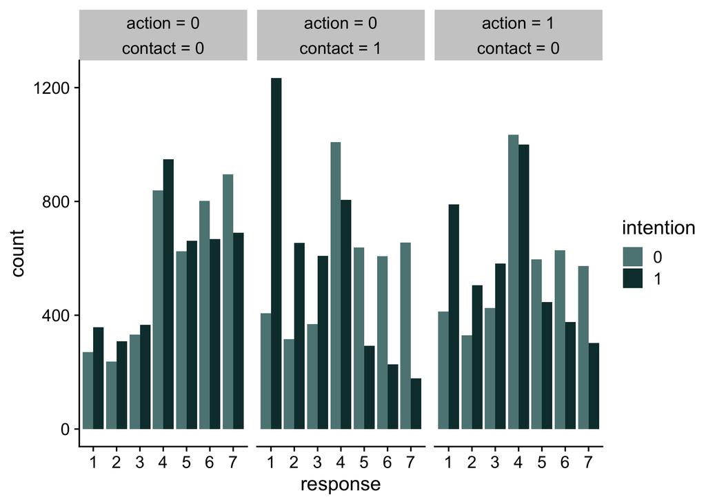

```r
f %>%
  as.data.frame() %>%
  mutate(
    across( c(action, contact, intention) ,
            as.character),
    action  = str_c("action = ",  action),
    contact = str_c("contact = ", contact)) %>%
  count(action, contact, intention, .prediction) %>%
  ggplot( aes(x=.prediction, y=n, fill=intention) )+
  geom_bar( stat="identity", position="dodge" ) +
  facet_grid(~action+contact) +
  labs( x="response",
        y="count" )
```

### exercise

Create a new model that includes only the main effects of action, contact, and intention (no interactions). Then:

1. Compare the coefficients between this model and m2 (the model with interactions)
2. Compare the fits of these models using PSIS and WAIC.

### solution

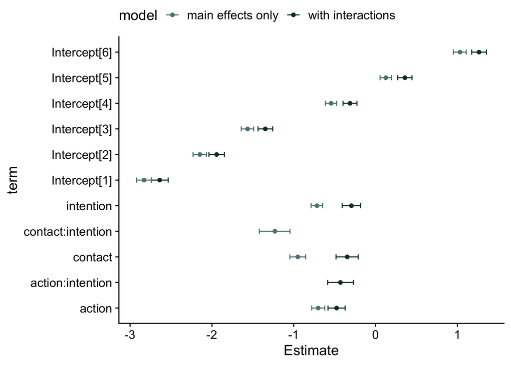

```r
# Fit simpler model
m2_simple <- brm(
  data = trolley,
  family = cumulative,
  response ~ 1 + action + contact + intention,
  prior = c(prior(normal(0, 1.5), class = Intercept),
            prior(normal(0, 0.5), class = b)),
  iter = 2000, warmup = 1000, cores = 4, chains = 4,
  file=here("files/data/generated_data/m61.2simple")
)

# Compare coefficients
bind_rows(
  fixef(m2) %>% as_tibble(rownames = "term"),
  fixef(m2_simple) %>% as_tibble(rownames = "term")
) %>%
  mutate(model = rep(c("with interactions", "main effects only"), each = n()/2)) %>%
  ggplot(aes(x = term, y = Estimate, color = model)) +
  geom_point() +
  geom_errorbar(aes(ymin = Q2.5, ymax = Q97.5), width = 0.2) +
  coord_flip() +
  theme(legend.position = "top")
```

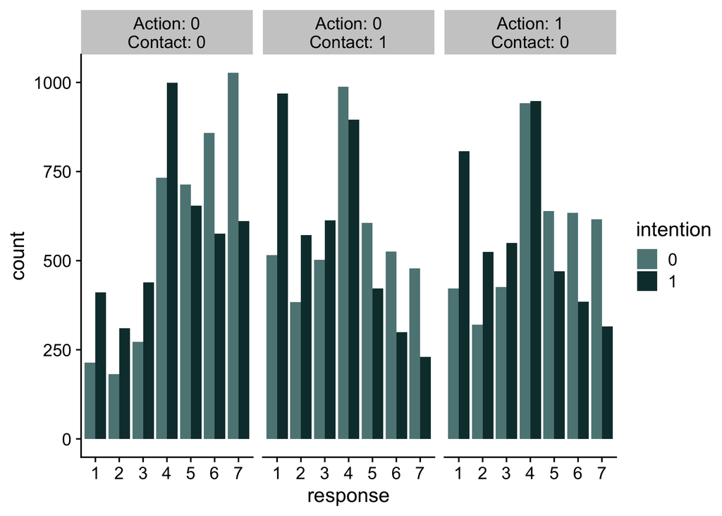

```r
# Plot predictions
predicted_draws(m2_simple, newdata = nd) %>%
  as.data.frame() %>%
  mutate(
    across(c(action, contact, intention), as.character),
    facet_title = str_c("Action: ", action,
                        "\nContact: ", contact)
  ) %>%
  count(facet_title, intention, .prediction) %>%
  ggplot(aes(x = .prediction, y = n, fill = intention)) +
  geom_bar(stat = "identity", position = "dodge") +
  facet_wrap(~facet_title) +
  labs(x = "response", y = "count")
```

```r
m2  <-       add_criterion(m2,        "loo")
m2_simple <- add_criterion(m2_simple, "loo")

loo_compare(m2, m2_simple, criterion = "loo") %>%
  print(simplify = F)
```

```
##           elpd_diff se_diff  elpd_loo se_elpd_loo p_loo    se_p_loo looic
## m2             0.0       0.0 -18464.7     40.4        11.1      0.1  36929.4
## m2_simple    -80.4      12.4 -18545.1     38.0         9.1      0.0  37090.2
##           se_looic
## m2            80.8
## m2_simple     75.9
```

```r
m2  <-       add_criterion(m2,        "waic")
m2_simple <- add_criterion(m2_simple, "waic")

loo_compare(m2, m2_simple, criterion = "waic") %>%
  print(simplify = F)
```

```
##           elpd_diff se_diff  elpd_waic se_elpd_waic p_waic   se_p_waic waic
## m2             0.0       0.0 -18464.7      40.4         11.0      0.1   36929.4
## m2_simple    -80.4      12.4 -18545.1      38.0          9.1      0.0   37090.2
##           se_waic
## m2            80.8
## m2_simple     75.9
```

## Ordered categorical predictors

```r
distinct(trolley, edu)
```

```
##                    edu
## 1        Middle School
## 2    Bachelor's Degree
## 3         Some College
## 4      Master's Degree
## 5 High School Graduate
## 6      Graduate Degree
## 7     Some High School
## 8    Elementary School
```

```r
trolley <-
  trolley %>%
  mutate(edu_new =
           recode(edu,
                  "Elementary School" = 1,
                  "Middle School" = 2,
                  "Some High School" = 3,
                  "High School Graduate" = 4,
                  "Some College" = 5,
                  "Bachelor's Degree" = 6,
                  "Master's Degree" = 7,
                  "Graduate Degree" = 8) %>%
           as.integer())
```

To incorporate this variable as a **MONOTONIC CATEOGORICAL PREDICTOR**, we’ll set up a notation such that each step up in value comes with its own incremental or marginal effect on the outcome.

$$\phi_i = \sum_{j=1}^7 \delta_j$$
We only need 7 because the first category is absorbed into the intercept for $\phi$. So our full formula for this parameter is:
$$\phi_i = \beta_1\text{action}_i + \beta_2\text{contact}_i +
\beta_3\text{intention}_i + \beta_E\sum_{j=0}^{E_i-1} \delta_j$$
where $\beta_E$ is the average effect

$$\begin{align*}
\text{response}_i &\sim \text{Categorical}(\mathbf{p}) \\
\text{logit}(p_k) &= \alpha_k - \phi_i \\
\phi_i &= \beta_1\text{action}_i + \beta_2\text{contact}_i +
\beta_3\text{intention}_i + \beta_4 \text{ mo(edu\_new}_i,
\boldsymbol{\delta}) \\
\alpha_k &\sim \text{Normal}(0, 1.5) \\
\beta_1, \ldots, \beta_3 &\sim \text{Normal}(0, 1) \\
\beta_4 &\sim \text{Normal}(0, 0.143) \\
\boldsymbol{\delta} &\sim \text{Dirichlet}(2, 2, 2, 2, 2, 2, 2),
\end{align*}$$

```r
m3 <-
  brm(data = trolley,
      family = cumulative,
      response ~ 1 + action + contact + intention + mo(edu_new),  # note the `mo()` syntax
      prior = c(prior(normal(0, 1.5), class = Intercept),
                prior(normal(0, 1), class = b),
                # note the new kinds of prior statements
                prior(normal(0, 0.143), class = b, coef = moedu_new),
                prior(dirichlet(2, 2, 2, 2, 2, 2, 2), class = simo, coef = moedu_new1)),
      iter = 2000, warmup = 1000, cores = 4, chains = 4,
      seed = 12,
      file = here("files/data/generated_data/m61.3"))
```

```r
m3
```

```
##  Family: cumulative
##   Links: mu = logit; disc = identity
## Formula: response ~ 1 + action + contact + intention + mo(edu_new)
##    Data: trolley (Number of observations: 9930)
##   Draws: 4 chains, each with iter = 2000; warmup = 1000; thin = 1;
##          total post-warmup draws = 4000
##
## Regression Coefficients:
##              Estimate Est.Error l-95% CI u-95% CI Rhat Bulk_ESS Tail_ESS
## Intercept[1]    -3.13      0.17    -3.53    -2.84 1.00     1707     2012
## Intercept[2]    -2.45      0.17    -2.83    -2.16 1.00     1702     1934
## Intercept[3]    -1.87      0.17    -2.25    -1.58 1.00     1708     1804
## Intercept[4]    -0.85      0.17    -1.23    -0.56 1.00     1731     1956
## Intercept[5]    -0.18      0.17    -0.56     0.11 1.00     1718     1925
## Intercept[6]     0.73      0.17     0.35     1.01 1.00     1737     1988
## action          -0.71      0.04    -0.78    -0.63 1.00     4604     3182
## contact         -0.96      0.05    -1.06    -0.86 1.00     4521     2761
## intention       -0.72      0.04    -0.79    -0.65 1.00     4514     2992
## moedu_new       -0.05      0.03    -0.11    -0.00 1.00     1705     1866
##
## Monotonic Simplex Parameters:
##               Estimate Est.Error l-95% CI u-95% CI Rhat Bulk_ESS Tail_ESS
## moedu_new1[1]     0.26      0.15     0.04     0.59 1.00     2292     3104
## moedu_new1[2]     0.14      0.09     0.02     0.35 1.00     4405     2501
## moedu_new1[3]     0.19      0.11     0.03     0.44 1.00     4005     2613
## moedu_new1[4]     0.16      0.09     0.03     0.39 1.00     3636     2564
## moedu_new1[5]     0.04      0.05     0.00     0.15 1.00     2606     1894
## moedu_new1[6]     0.09      0.06     0.01     0.25 1.00     3747     2484
## moedu_new1[7]     0.12      0.07     0.02     0.29 1.00     3829     2596
##
## Further Distributional Parameters:
##      Estimate Est.Error l-95% CI u-95% CI Rhat Bulk_ESS Tail_ESS
## disc     1.00      0.00     1.00     1.00   NA       NA       NA
##
## Draws were sampled using sampling(NUTS). For each parameter, Bulk_ESS
## and Tail_ESS are effective sample size measures, and Rhat is the potential
## scale reduction factor on split chains (at convergence, Rhat = 1).
```

Let’s see the effect of education after controlling for story parameters.

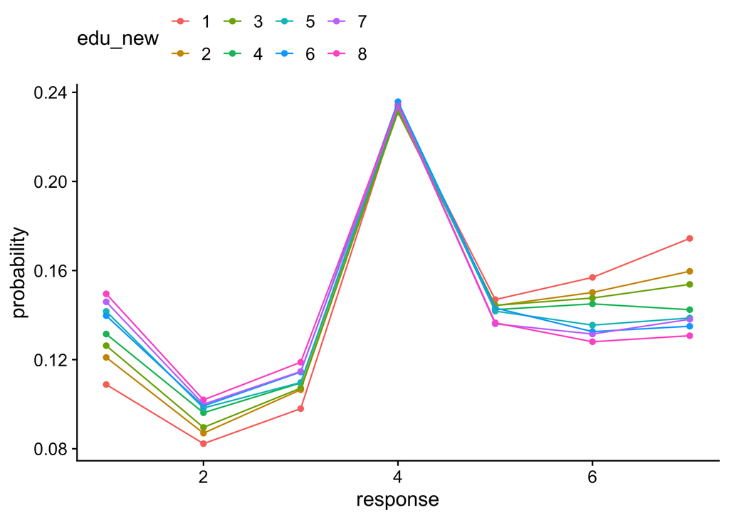

```r
nd <- distinct(
  trolley,
  action, contact, intention, edu_new
)
predicted_draws(m3, nd) %>%
  ungroup() %>%
  count(edu_new, .prediction) %>%
  with_groups(edu_new, mutate, total=sum(n)) %>%
  mutate(pk = n/total,
         .prediction = as.numeric(.prediction),
         edu_new = as.factor(edu_new)) %>%
  ggplot(aes(x = .prediction,  y = pk, color = edu_new)) +
  geom_point() +
  geom_line() +
  labs( x="response",
        y="probability" ) +
  theme(legend.position = "top")
```

### exercise

Create a new model that includes education as a regular categorical predictor (not monotonic) and compare it to m3. Your tasks:

1. Fit the model using the original `edu` variable (not `edu_new`)
2. Create a plot comparing the predicted probabilities between the two models
3. Use create a side-by-side visual comparison of the education effects
4. Interpret whether the monotonic constraint appears to improve the model fit

### solution

```r
# Fit model with regular categorical education
m3_cat <- brm(
  data = trolley,
  family = cumulative,
  response ~ 1 + action + contact + intention + edu,
  prior = c(prior(normal(0, 1.5), class = Intercept),
            prior(normal(0, 1), class = b)),
  iter = 2000, warmup = 1000, cores = 4, chains = 4,
  file=here("files/data/generated_data/m61.3cat")
)

m3_cat
```

```
##  Family: cumulative
##   Links: mu = logit; disc = identity
## Formula: response ~ 1 + action + contact + intention + edu
##    Data: trolley (Number of observations: 9930)
##   Draws: 4 chains, each with iter = 2000; warmup = 1000; thin = 1;
##          total post-warmup draws = 4000
##
## Regression Coefficients:
##                       Estimate Est.Error l-95% CI u-95% CI Rhat Bulk_ESS
## Intercept[1]             -2.96      0.06    -3.06    -2.85 1.00     2652
## Intercept[2]             -2.28      0.05    -2.37    -2.18 1.00     2864
## Intercept[3]             -1.69      0.05    -1.78    -1.60 1.00     2906
## Intercept[4]             -0.66      0.04    -0.75    -0.57 1.00     2938
## Intercept[5]              0.01      0.04    -0.07     0.10 1.00     3128
## Intercept[6]              0.92      0.05     0.83     1.02 1.00     3422
## action                   -0.71      0.04    -0.79    -0.63 1.00     3688
## contact                  -0.96      0.05    -1.06    -0.86 1.00     4052
## intention                -0.72      0.04    -0.79    -0.65 1.00     4802
## eduElementarySchool       0.90      0.21     0.49     1.30 1.00     5182
## eduGraduateDegree        -0.18      0.06    -0.30    -0.05 1.00     3974
## eduHighSchoolGraduate    -0.06      0.07    -0.19     0.07 1.00     4515
## eduMastersDegree         -0.11      0.06    -0.22    -0.00 1.00     4173
## eduMiddleSchool          -0.26      0.15    -0.54     0.03 1.00     5264
## eduSomeCollege           -0.31      0.05    -0.40    -0.22 1.00     4140
## eduSomeHighSchool         0.13      0.09    -0.05     0.31 1.00     5128
##                       Tail_ESS
## Intercept[1]              2505
## Intercept[2]              2724
## Intercept[3]              2652
## Intercept[4]              3064
## Intercept[5]              3014
## Intercept[6]              3240
## action                    2941
## contact                   2989
## intention                 3222
## eduElementarySchool       2776
## eduGraduateDegree         2930
## eduHighSchoolGraduate     3103
## eduMastersDegree          3194
## eduMiddleSchool           3190
## eduSomeCollege            3030
## eduSomeHighSchool         3042
##
## Further Distributional Parameters:
##      Estimate Est.Error l-95% CI u-95% CI Rhat Bulk_ESS Tail_ESS
## disc     1.00      0.00     1.00     1.00   NA       NA       NA
##
## Draws were sampled using sampling(NUTS). For each parameter, Bulk_ESS
## and Tail_ESS are effective sample size measures, and Rhat is the potential
## scale reduction factor on split chains (at convergence, Rhat = 1).
```

### solution

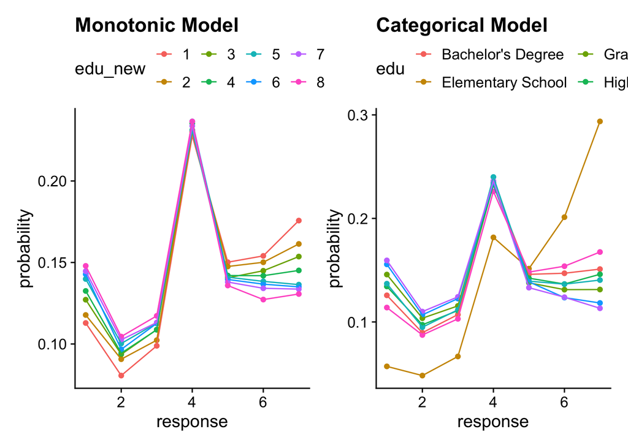

```r
# Create predictions for both models
p1 <- predicted_draws(m3, nd) %>%
  ungroup() %>%
  count(edu_new, .prediction) %>%
  with_groups(edu_new, mutate, total = sum(n)) %>%
  mutate(pk = n/total,
         .prediction = as.numeric(.prediction),
         edu_new = as.factor(edu_new)) %>%
  ggplot(aes(x = .prediction, y = pk, color = edu_new)) +
  geom_point() +
  geom_line() +
  labs(x = "response", y = "probability", title = "Monotonic Model") +
  theme(legend.position = "top")

p2 <- predicted_draws(m3_cat, newdata = distinct(trolley, action, contact, intention, edu)) %>%
  ungroup() %>%
  count(edu, .prediction) %>%
  with_groups(edu, mutate, total = sum(n)) %>%
  mutate(pk = n/total,
         .prediction = as.numeric(.prediction)) %>%
  ggplot(aes(x = .prediction, y = pk, color = edu)) +
  geom_point() +
  geom_line() +
  labs(x = "response", y = "probability", title = "Categorical Model") +
  theme(legend.position = "top")

# Combine plots
p1 + p2
```

[^1]: Actual counts communicate meaningful and consistent distance between possible values.